# PSet 4

Yavuz Ramiz Çolak, Ryo Tamaki, David Lieberman, Liana Wang

3/10/2019

## PROBLEM 1

1). Evaluate the assumptions implicit to Discriminant Analysis for your data – multivariate normality WITHIN each group (i.e. chi-square quantile plots) and similarity of covariances matrices (look at Box’s M or just look at raw standard deviations/covariance matrices). Comment on what you find. Comment on whether you think transformations might help your data to meet the assumptions of DA. If you think they might, make some transformations and find out! You might also want to make a matrix plot (or a pairs plot) to get a sense of what your data looks like two variables at a time (use different symbols for each group).

```r
data <- read.csv("https://pastebin.com/raw/LQ7WWrEC")
data <- as.data.frame(data)
head(data)
```

```
##   subj trecall hirecall lirecall tunrem hiunrem liunrem store recog group
## 1    9      41       22       19  0.025    0.05    0.00  0.20     7     1
## 2    7      44       25       19  0.195    0.17    0.22  0.70    11     1
## 3   10      38       17       21  0.025    0.00    0.05  0.25     8     1
## 4    1      48       22       26  0.025    0.05    0.00  0.00     7     1
## 5    3      24       10       14  0.035    0.00    0.07  0.40    10     1
## 6    5      36       21       15  0.000    0.00    0.00  0.00     8     1
```

### Evaluating Univariate Normality (Exploratory)

To evaluate univariate normality, we create boxplots of variables of interest by groups.

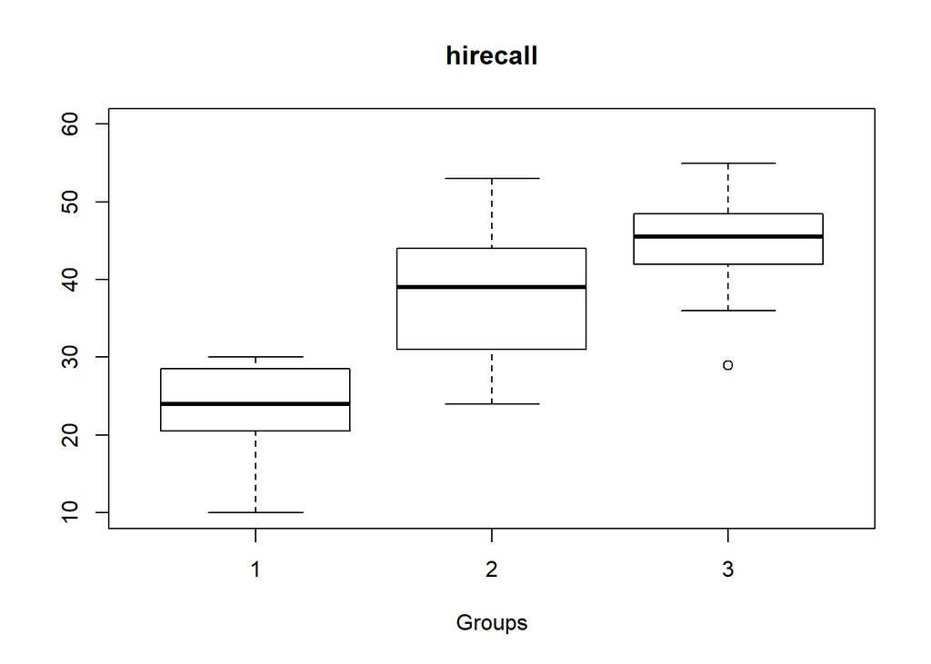

```r
boxplot(hirecall ~ group, data=data, xlab="Groups", main="hirecall", ylim=c(10,60))
```

Our box plot of ‘hirecall’ shows an approximately normal distribution for groups 2 and 3 group, while group 1 has a heavy left skew.

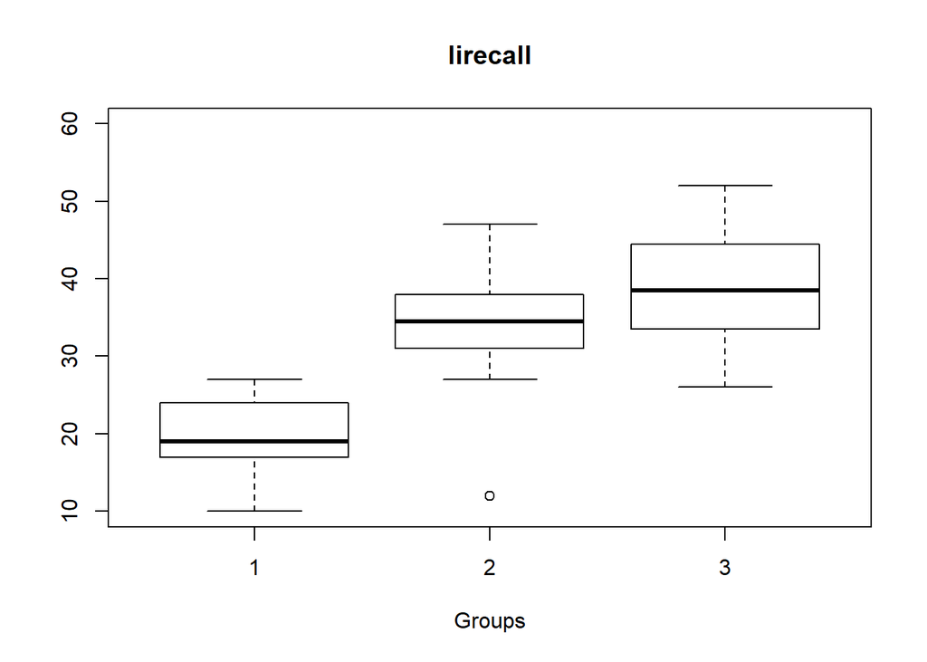

```r
boxplot(lirecall ~ group, data=data, xlab="Groups", main="lirecall", ylim=c(10,60))
```

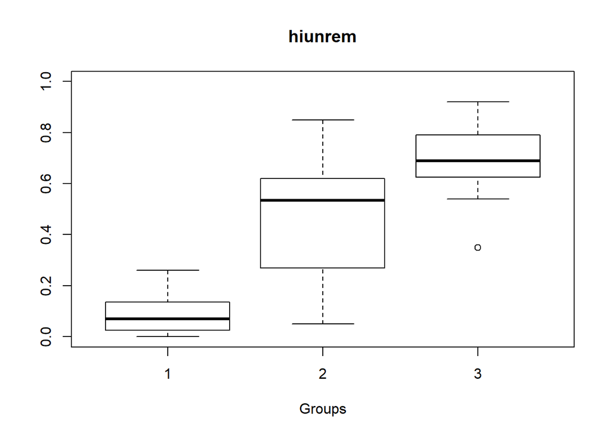

```r
boxplot(hiunrem ~ group, data=data, xlab="Groups", main="hiunrem", ylim=c(0,1))
```

The groups seem mostly normally distributed, except group 1 seems to have a moderate right skew this time when measuring HI imagery unreminded memory, as opposed to HI Imagery recall as from our ‘hirecall’ boxplot above.

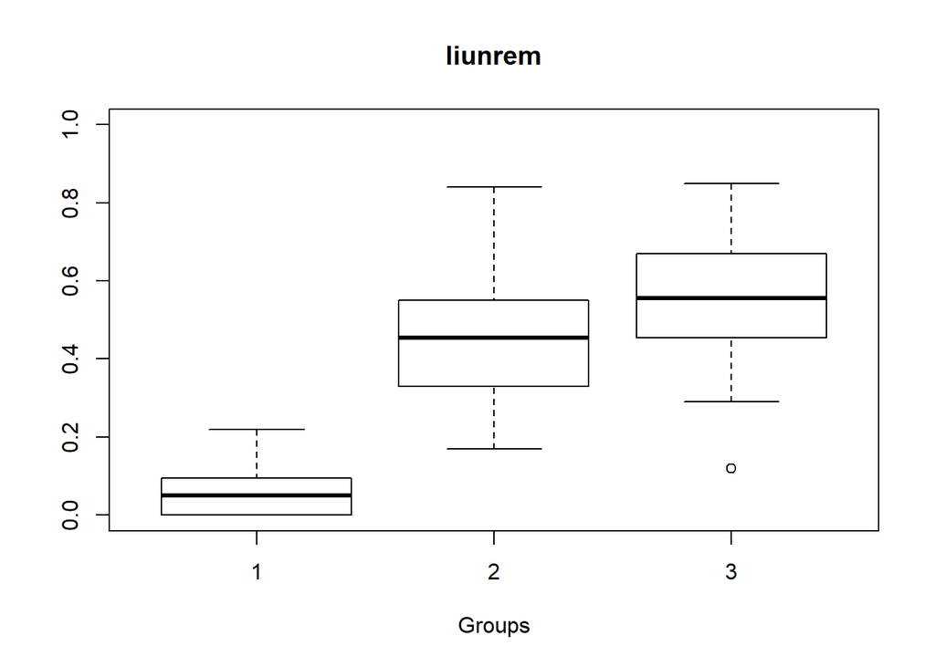

```r
boxplot(liunrem ~ group, data=data, xlab="Groups", main="liunrem", ylim=c(0,1))
```

The groups appear to remain be mostly normally distributed, except for group 1 which has a strong right skew this time when measuring LO imagery unreminded memory, as opposed to LO Imagery recall as from our ‘lirecall’ boxplot above.

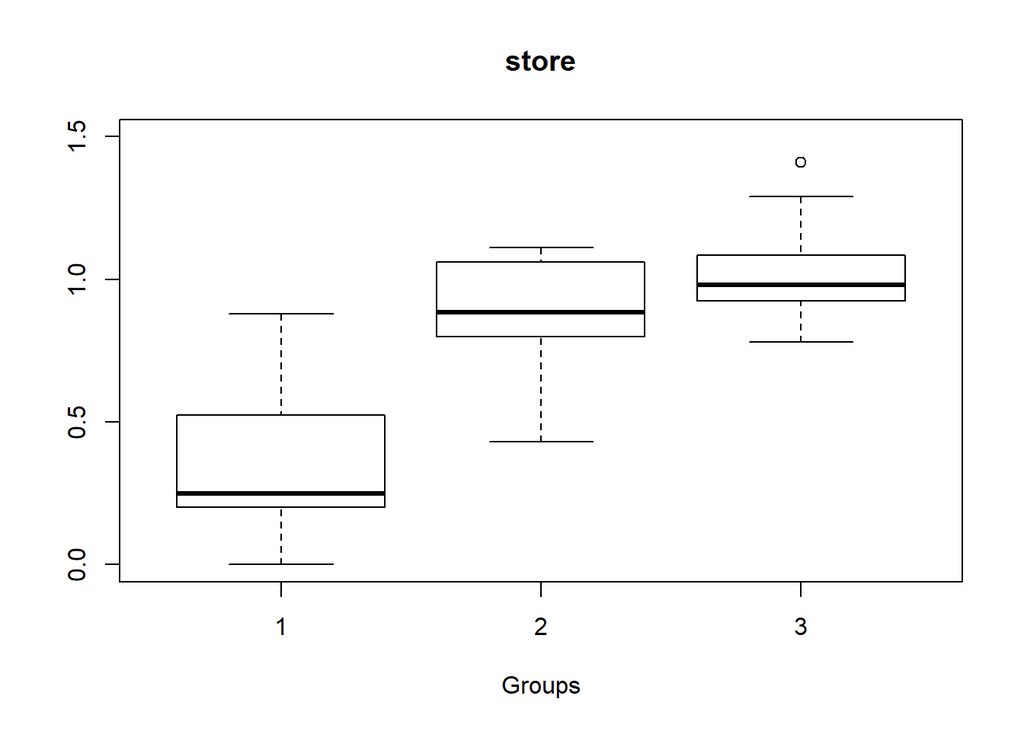

```r
boxplot(store ~ group, data=data, xlab="Groups", main="store", ylim=c(0,1.5))
```

Groups 1 and 2 are visibly, though not extremely skewed right and left, respectively, while group 3 is approximately Normal (save for one outlier).

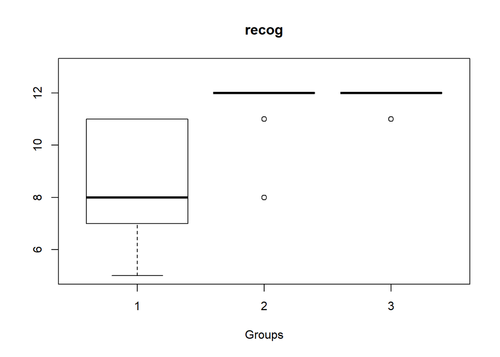

```r
boxplot(recog ~ group, data=data, xlab="Groups", main="recog", ylim=c(5,13))
```

This boxplot is very interesting, because it illustrates group 2 and 3’s nearly nonexistent spreads. Conversely, group 1, although skewed from Normal, has a very wide range of response values for recognition memory. Note that this is a categorical variable. Regardless, we obtain useful information from these boxplots.

Overall, looking at all these boxplots for each explanatory variable, while there are some cases of a group skewed from Normal, the on the whole, each of these explanatory variable data seem to approximately follow a univariate Normal distribution.

```r
QQPlot <- function(x, na.rm = TRUE){
  plots <- list()
  j <- 1
  for (i in names(x)) {
    plots[[i]] <- ggplot(x, aes_string(sample = i)) + stat_qq() + stat_qq_line() + xlab(names(x)[j]) + ylab("")
    j <- j+1
  }
  plot_grid(plotlist = plots)
}

data_group1 <- data[data$group == 1,c(3:4,6:9)]
data_group2 <- data[data$group == 2,c(3:4,6:9)]
data_group3 <- data[data$group == 3,c(3:4,6:9)]
```

#### Group 1

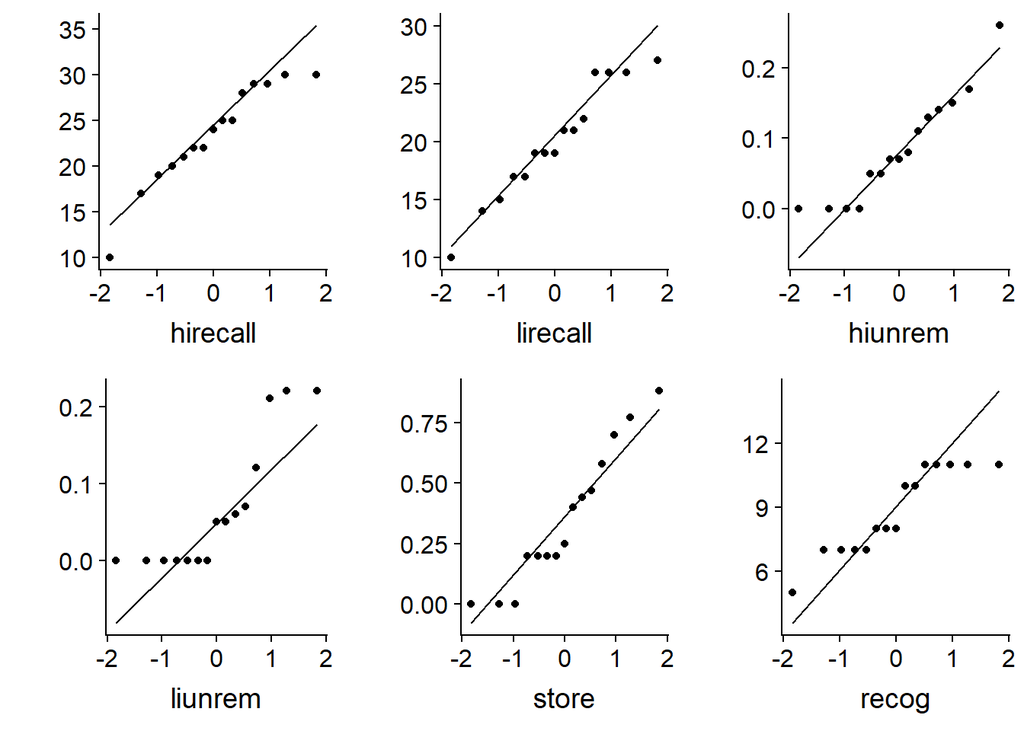

```r
QQPlot(data_group1)
```

As observed in the skewness in some of our boxplots of group 1 above, there are some notable deviations from univariate Normality, but on the whole, we don’t think these deviations will be serious enough to impede our analysis going forward, and we will conclude that overall that the group 1 data for each of the explanatory variables approximately follows a univariate Normal distribution.

#### Group 2

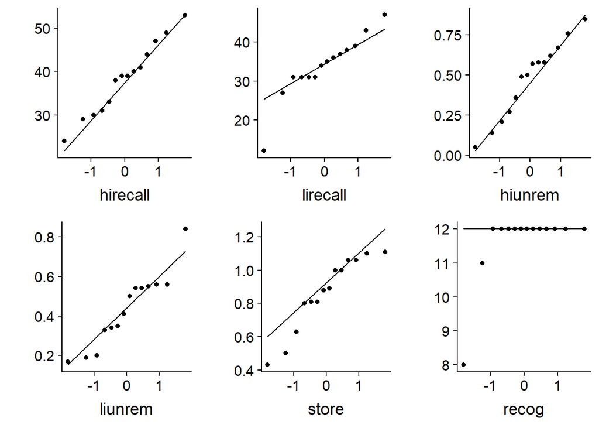

```r
QQPlot(data_group2)
```

These univariate quantile-quantile plots look much better for group 2, and despite some deviations for store and liunrem, and single outliers in lirecall and recog, group 2 data for all explanatory variables follow an approximately univariate Normal distribution.

#### Group 3

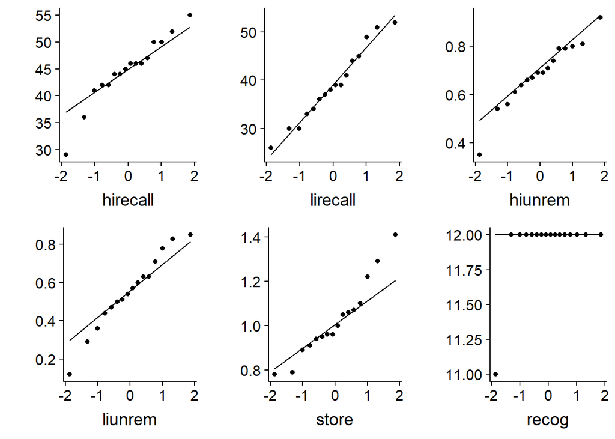

```r
QQPlot(data_group3)
```

These univariate quantile-quantile plots for group 3 look great! Group 3 data for all explanatory variables follow an approximately univariate Normal distribution.

### Evaluating Multivariate Normality

To evaluate multivariate normality within groups, we plot chi-square quantile-quantile plots for each group.

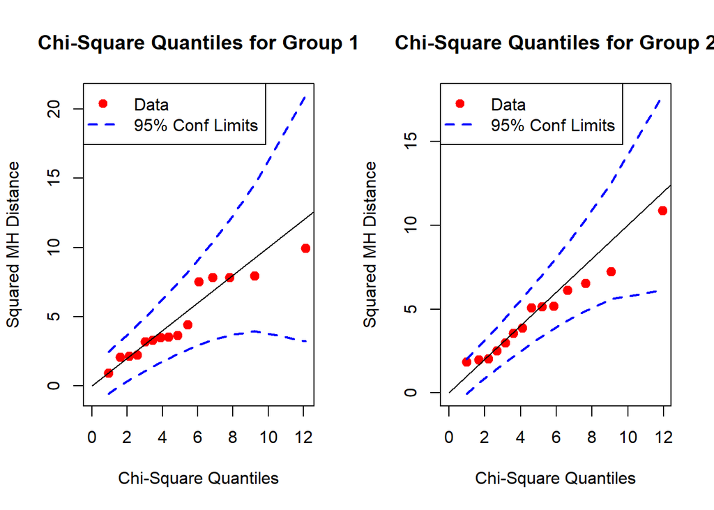

```r
source("http://www.reuningscherer.net/STAT660/R/CSQPlot.r.txt")

par(mfrow=c(1,2))
CSQPlot(data[data$group == 1, c(3,4,6,7,8)], label="Group 1")
CSQPlot(data[data$group == 2, c(3,4,6,7,8)], label="Group 2")
```

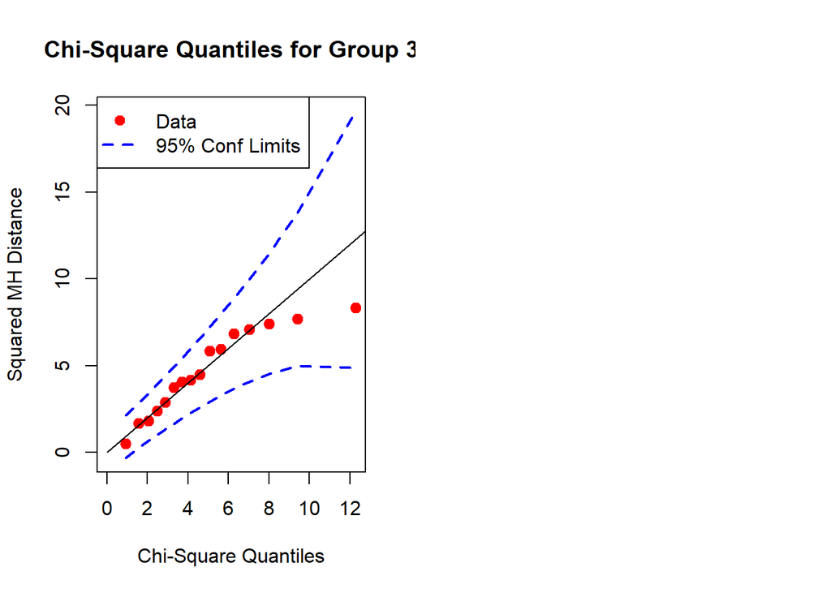

```r
CSQPlot(data[data$group == 3, c(3,4,6,7,8)], label="Group 3")
```

Since the data falls within the 95% confidence intervals for every group, it is safe to consider the data roughly multivariate normal and thus, we can use our data set for discriminant analysis. Because normality assumptions are roughly fulfilled, we see no need to transform our data.

### Evaluating Similarity of Covariances Matrices

Matrix plot to look at differences between groups

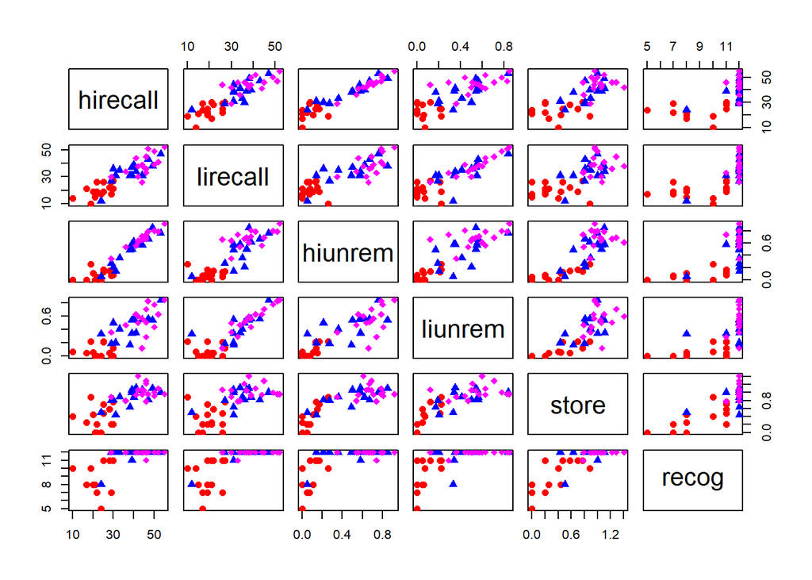

```r
plot(data[,c(3:4,6:9)], col = 2*(as.numeric(data$group)), pch = as.numeric(data$group)+15,cex=1.2)
```

```r
for (i in 1:3){
  print(paste("Covariance Matrix for Group", i))
  covariance <- cov(data[data$group == i, c(3:4,6:9)])
  print(covariance)
  cat(c("log-determinant", log(det(covariance)), "\n\n"))
}
```

```
## [1] "Covariance Matrix for Group 1"
##             hirecall    lirecall      hiunrem      liunrem       store
## hirecall 31.25714286 15.10000000  0.124857143 -0.051428571  0.04100000
## lirecall 15.10000000 24.63809524 -0.013904762 -0.041666667 -0.12623810
## hiunrem   0.12485714 -0.01390476  0.005683810  0.004819048  0.01819190
## liunrem  -0.05142857 -0.04166667  0.004819048  0.007295238  0.02013810
## store     0.04100000 -0.12623810  0.018191905  0.020138095  0.08036381
## recog     1.22857143  1.05714286  0.090428571  0.112857143  0.42057143
##               recog
## hirecall 1.22857143
## lirecall 1.05714286
## hiunrem  0.09042857
## liunrem  0.11285714
## store    0.42057143
## recog    4.02857143
## log-determinant -8.94117223810046
##
## [1] "Covariance Matrix for Group 2"
##           hirecall  lirecall    hiunrem    liunrem      store      recog
## hirecall 68.554945 52.648352 1.86884615 1.07527473 1.18813187 4.36813187
## lirecall 52.648352 67.142857 1.40461538 1.02439560 0.94395604 6.89010989
## hiunrem   1.868846  1.404615 0.05624231 0.02670769 0.03874615 0.12269231
## liunrem   1.075275  1.024396 0.02670769 0.03447253 0.02293297 0.03934066
## store     1.188132  0.943956 0.03874615 0.02293297 0.04742198 0.10109890
## recog     4.368132  6.890110 0.12269231 0.03934066 0.10109890 1.17032967
## log-determinant -7.96328337866865
##
## [1] "Covariance Matrix for Group 3"
##            hirecall lirecall       hiunrem    liunrem        store
## hirecall 38.4958333 28.46667  0.8045416667 0.56262500 0.1759166667
## lirecall 28.4666667 58.93333  0.6220000000 1.39200000 0.0920000000
## hiunrem   0.8045417  0.62200  0.0178129167 0.01220208 0.0006708333
## liunrem   0.5626250  1.39200  0.0122020833 0.03825625 0.0071725000
## store     0.1759167  0.09200  0.0006708333 0.00717250 0.0289716667
## recog    -0.0875000  0.40000 -0.0036250000 0.01745833 0.0162500000
##                recog
## hirecall -0.08750000
## lirecall  0.40000000
## hiunrem  -0.00362500
## liunrem   0.01745833
## store     0.01625000
## recog     0.06250000
## log-determinant -12.3835236694435
```

By visual inspection, we can see that the covariance matrices seem to be quite different. Some notible examples include the group 2 hirecall-recog covariance to be 4.368, while in group 3 it is -0.0875; additionally, the group 1 hirecall-lirecall covariance is 15.100, while in group 2 it is 52.648. Furthermore, the log-determinants for each group seem to be quite different as well: -8.9412, -7.963, and -12.384 for groups 1, 2, and 3, respectively.

```r
boxM(data[,c("hirecall","lirecall","hiunrem","liunrem","store","recog")], data$group)
```

```
##
##  Box's M-test for Homogeneity of Covariance Matrices
##
## data:  data[, c("hirecall", "lirecall", "hiunrem", "liunrem", "store",     "recog")]
## Chi-Sq (approx.) = 142.1, df = 42, p-value = 8.506e-13
```

It comes as no suprise that the Box’s M test yields an approximately zero p-value, registering a significant difference between each group’s covariance matrix, as alluded to from our earlier visual inspection of substantial differences in covariance matrix elements and log-determinants between groups. These significant differences between each group’s covariance matrix means that our data set is not suitable for Linear Discriminant Analysis. Therefore, we will proceed by doing Quadratic Discriminant Analysis instead. Despite the differences between covariance matrices, according to our chi-squared quantile-quantile plots above, our groups have an approximately multivariate Normal distribution within groups, which is enough to make our data suitable for QDA.

## PROBLEM 2

2). Perform stepwise discriminant analysis on your data. Comment on which model seems the best. Use quadratic discriminant analysis if appropriate. If you end up with only one significant discriminating variable, you might want to just force a second variable in the model (i.e. add a technically ‘nonsignificant’ discriminator).

```r
alz.data <- data[,c(3:4,6:9)] # the data
alz.group <- data[,10] # the classes
alz.stepwise.qda <- stepclass(alz.data, alz.group, "qda", start.vars = "liunrem")
```

```
##  `stepwise classification', using 10-fold cross-validated correctness rate of method qda'.
```

```
## 45 observations of 6 variables in 3 classes; direction: both
```

```
## stop criterion: improvement less than 5%.
```

```
## correctness rate: 0.59;  starting variables (1): liunrem
```

```
## correctness rate: 0.71;  in: "hirecall";  variables (2): liunrem, hirecall
```

```
## correctness rate: 0.78;  in: "hiunrem";  variables (3): liunrem, hirecall, hiunrem
```

```
##
##  hr.elapsed min.elapsed sec.elapsed
##        0.00        0.00        0.45
```

```r
alz.stepwise.qda
```

```
## method      : qda
## final model : alz.group ~ hirecall + hiunrem + liunrem
## <environment: 0x0000000031d7b508>
##
## correctness rate = 0.78
```

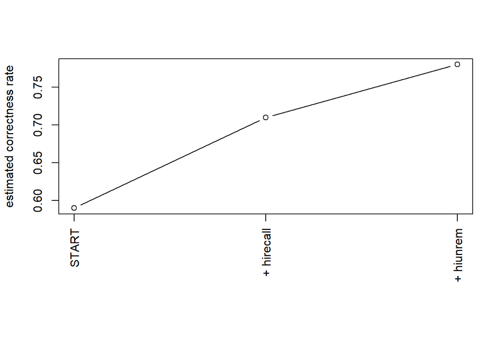

```r
plot(alz.stepwise.qda)
```

## PROBLEM 3

3). Comment on whether there is statistical evidence that the multivariate group means are different (i.e. Wilks’ Lambda test).

```r
alz.manova <- manova(as.matrix(data[,c(3:4,6:9)]) ~ data$group)
```

```r
summary.aov(alz.manova)
```

```
##  Response hirecall :
##             Df Sum Sq Mean Sq F value    Pr(>F)
## data$group   1 3480.9  3480.9  71.767 1.029e-10 ***
## Residuals   43 2085.6    48.5
## ---
## Signif. codes:  0 '***' 0.001 '**' 0.01 '*' 0.05 '.' 0.1 ' ' 1
##
##  Response lirecall :
##             Df Sum Sq Mean Sq F value    Pr(>F)
## data$group   1 2790.3 2790.26  52.722 5.401e-09 ***
## Residuals   43 2275.7   52.92
## ---
## Signif. codes:  0 '***' 0.001 '**' 0.01 '*' 0.05 '.' 0.1 ' ' 1
##
##  Response hiunrem :
##             Df Sum Sq Mean Sq F value    Pr(>F)
## data$group   1 2.7740 2.77402  103.26 5.294e-13 ***
## Residuals   43 1.1552 0.02686
## ---
## Signif. codes:  0 '***' 0.001 '**' 0.01 '*' 0.05 '.' 0.1 ' ' 1
##
##  Response liunrem :
##             Df Sum Sq Mean Sq F value    Pr(>F)
## data$group   1 1.8044 1.80443  60.865 9.071e-10 ***
## Residuals   43 1.2748 0.02965
## ---
## Signif. codes:  0 '***' 0.001 '**' 0.01 '*' 0.05 '.' 0.1 ' ' 1
##
##  Response store :
##             Df Sum Sq Mean Sq F value    Pr(>F)
## data$group   1 3.4514  3.4514  60.079 1.071e-09 ***
## Residuals   43 2.4702  0.0574
## ---
## Signif. codes:  0 '***' 0.001 '**' 0.01 '*' 0.05 '.' 0.1 ' ' 1
##
##  Response recog :
##             Df Sum Sq Mean Sq F value    Pr(>F)
## data$group   1 74.997  74.997  36.562 3.128e-07 ***
## Residuals   43 88.203   2.051
## ---
## Signif. codes:  0 '***' 0.001 '**' 0.01 '*' 0.05 '.' 0.1 ' ' 1
```

```r
summary.manova(alz.manova,test="Wilks")
```

```
##            Df   Wilks approx F num Df den Df    Pr(>F)
## data$group  1 0.27349   16.824      6     38 2.307e-09 ***
## Residuals  43
## ---
## Signif. codes:  0 '***' 0.001 '**' 0.01 '*' 0.05 '.' 0.1 ' ' 1
```

## PROBLEM 4

4). How many discriminant functions are significant? What is the relative discriminating power of each function?

## PROBLEM 5

5). Use classification, both regular and leave-one-out (or cross-validation) to evaluate the discriminating ability of your functions.

QDA, no cross validation

```r
alz.qda <- qda(data[,c("hirecall","lirecall","hiunrem","liunrem","store","recog")], grouping=data$group, CV=FALSE)
table(data$group, predict(alz.qda)$class)
```

```
##
##      1  2  3
##   1 14  1  0
##   2  0 12  2
##   3  0  0 16
```

When using all the availible data to construct the model, our classification results for quadratic discriminant analysis show that the discriminating ability of our discriminant functions were highly effective. Group 1 predictions were largely successful. Our model correctly predicted 14/15 group 1 individuals, with only 1/15 group 1 individuals being incorrectly placed into group 2. Group 2 predictions were largely successful. The discriminant functions placed only 12/14 group 2 individuals correctly, with 14.3% of group 2 individuals getting placed incorrectly in group 3. Group 3 predictions were entirely successful. Our model correctly predicted all 16/16 of Group 3 individuals. Contextualizing these results, it appears that the model is able to discern, with a 93.3% ‘accuracy’ rate, individuals with Alzheimers from both the control group and individuals with depression. However, the model’s biggest failure was in discerning depressed individuals from those who are not, with 14.3% truly depressed individuals being categorized as part of the control group. Finally, the model seems to be able to discern individuals in the control group extremely well. Overall, when using all the availible data to construct the model, the resulting discriminant functions are able to place data into the correct group with a 93.3% success rate.

```r
alz.cv.qda <- qda(data[,c("hirecall","lirecall","hiunrem","liunrem","store","recog")], grouping=data$group, CV=TRUE)
table(data$group, alz.cv.qda$class)
```

```
##
##      1  2  3
##   1 13  2  0
##   2  2  8  4
##   3  0  6 10
```

## PROBLEM 6

6). Provide some evidence as to which of your original variables are the ‘best’ discriminators amongst your groups (look at standardized discriminant coefficients).

## PROBLEM 7

7). Make score plots for the first two or three DA function scores (be sure to use different symbols/colors for each group). Comment on what you see.

Partition of original variable space using quadratic discriminant analysis

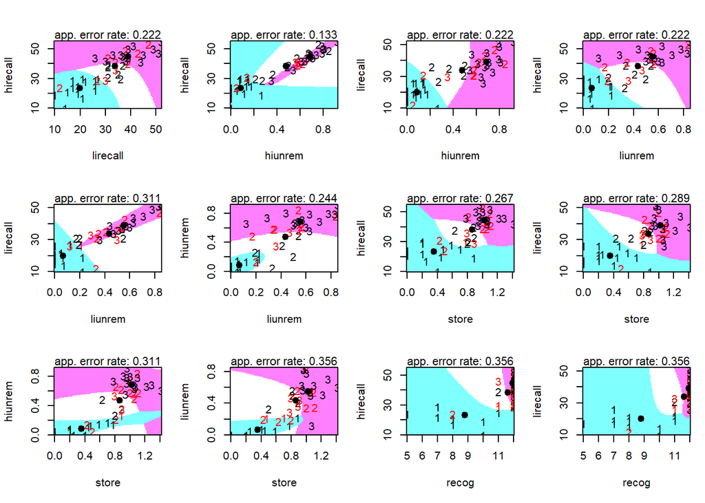

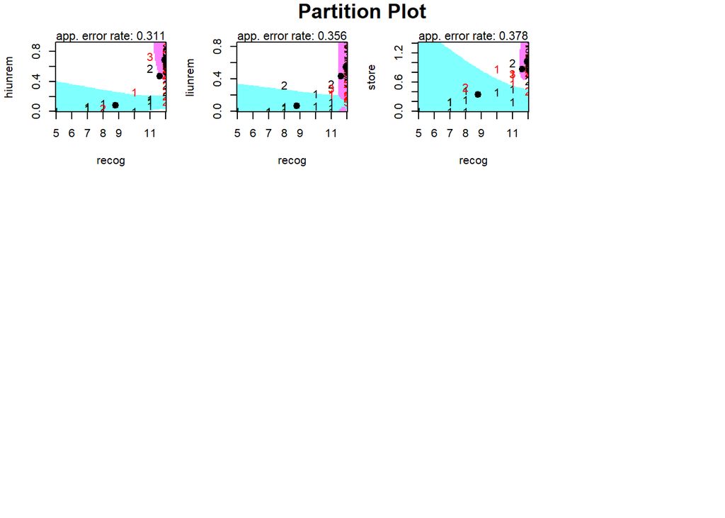

```r
partimat(as.factor(data$group)~hirecall+lirecall+hiunrem+liunrem+store+recog, data=data, method="qda")
```

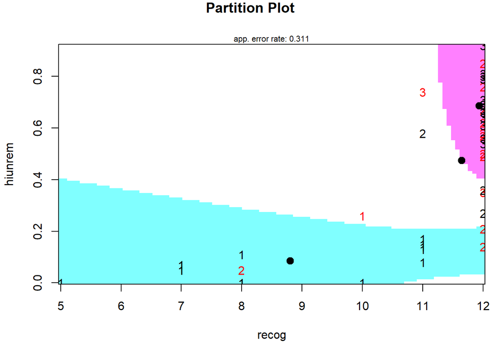

```r
partimat(as.factor(data$group)~hiunrem+recog, data=data, method="qda")
```

## PROBLEM 8

8). Bonus (and optional)– try kernel smoothing or k-nearest neighbors and get the admiration of your professor and TA (and some extra credit)! You’ll have to use SAS or R for this.

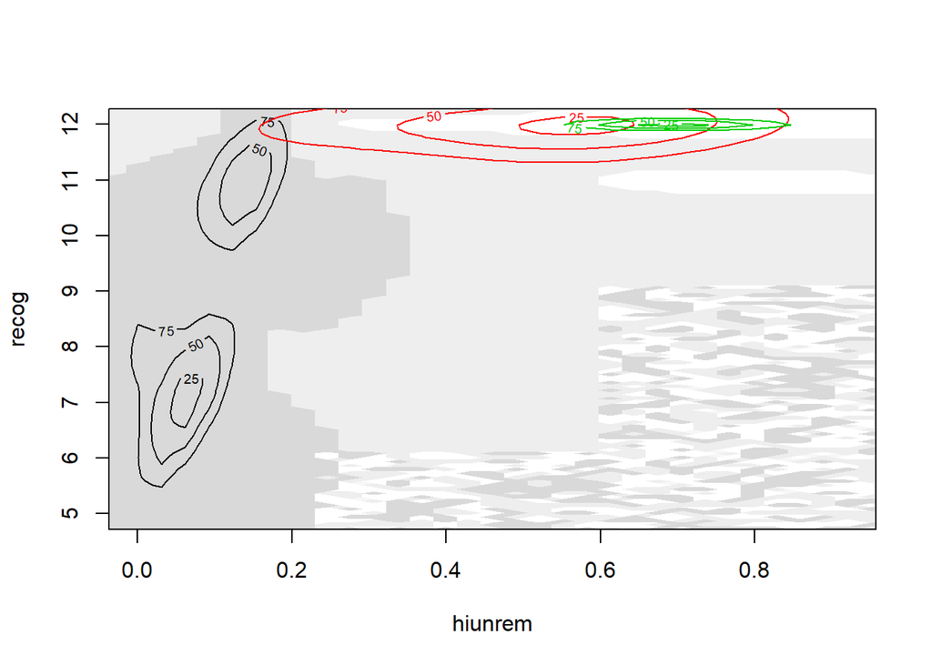

```r
data.var <- data[,c(6,9)]
data.gr <- data[,10]
kda.fhat <- kda(x=data.var, x.group=data.gr)
plot(kda.fhat)
```

```r
data.var <- data[,c(3,6,9)]
data.gr <- data[,10]
H <- Hkda(x=data.var, x.group=data.gr, bw="plugin")
kda.fhat <- kda(x=data.var, x.group=data.gr, Hs=H)
plot(kda.fhat)
```

[output not shown]

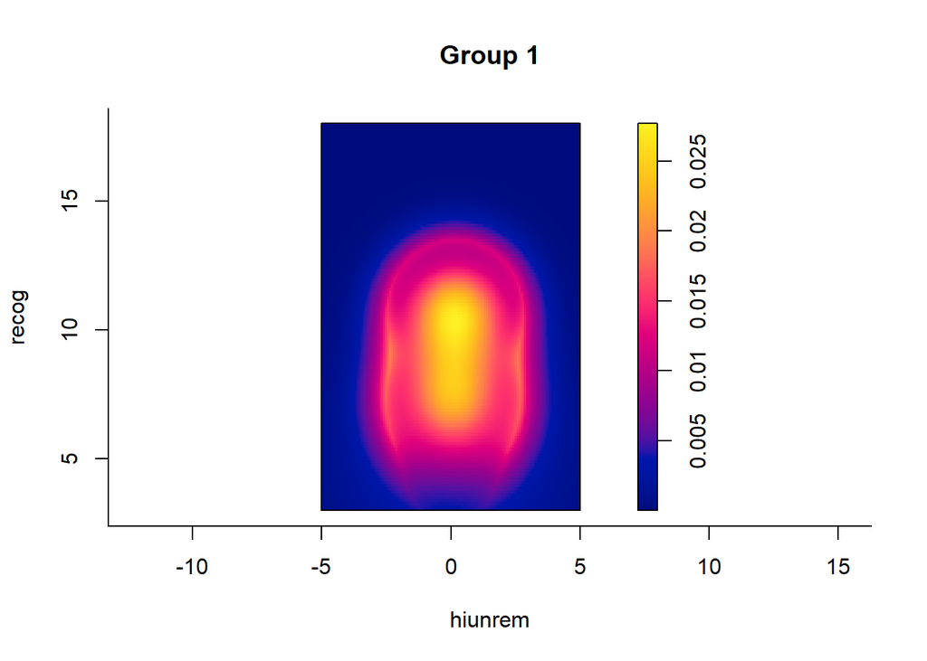

```r
x.1 <- jitter(data[data$group == 1,6],1)
y.1 <- jitter(data[data$group == 1,9],1)

x.2 <- jitter(data[data$group == 2,6],1)
y.2 <- jitter(data[data$group == 2,9],1)

x.3 <- jitter(data[data$group == 3,6],1)
y.3 <- jitter(data[data$group == 3,9],1)

pp.1 <- ppp(x.1, y.1, c(-5,5), c(3,18))
pp.2 <- ppp(x.2, y.2, c(-5,5), c(3,18))
pp.3 <- ppp(x.3, y.3, c(-5,5), c(3,18))

plot(bivariate.density(pp.1, h0=1.5, hp=1, adapt=TRUE), xlab="hiunrem", ylab="recog", main="Group 1")
```

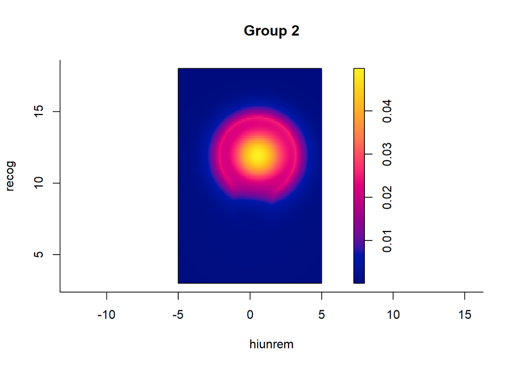

```r
plot(bivariate.density(pp.2, h0=1.5, hp=1, adapt=TRUE), xlab="hiunrem", ylab="recog", main="Group 2")
```

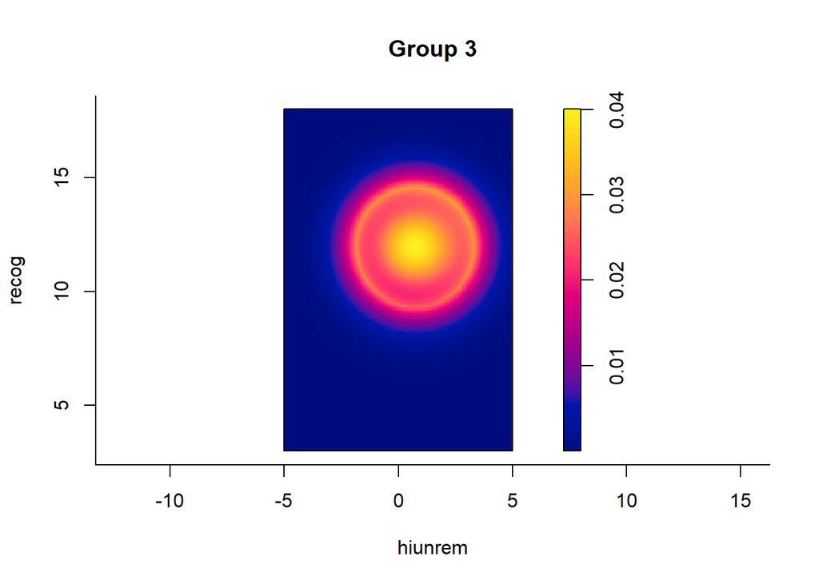

```r
plot(bivariate.density(pp.3, h0=1.5, hp=1, adapt=TRUE), xlab="hiunrem", ylab="recog", main="Group 3")
```

This is adaptive kernel smoothing for each group, using Abramson’s variable-bandwidth estimator as implemented in the ‘sparr’ package.

```r
results <- matrix(nrow = 45, ncol = 20)
for (j in 1:20) {
  for (i in 1:45) {
    test_point <- data[i,]
    train_data <- data[-i,]
    knn_prediction <- as.vector(knn(train = train_data[,c(6,9)], test = test_point[,c(6,9)], cl = train_data[,10], k = j))
    truth <- as.vector(data[i,10])
    results[i,j] <- truth == knn_prediction
  }
}

best_k <- which.max(colMeans(results))
best_k
```

```
## [1] 9
```

```r
success_rate <- colMeans(results)[best_k]
success_rate
```

```
## [1] 0.7555556
```